# Random_forest_examples

Raymaekers, J. and Rousseeuw, P.J.

2025-07-14

# Introduction

This vignette visualizes classification results from a random forest, using tools from the package.

```r
library(randomForest)
library(classmap)
```

# Instagram training data

We use the Instagram data to illustrate the visualization of a random forest classification. The data is on the identification of genuine/fake (spam) accounts on Instagram. The original data source is: https://www.kaggle.com/free4ever1/instagram-fake-spammer-genuine-accounts from Bardiya Bakhshandeh.

First we load and inspect the data.

```r
data("data_instagram")
traindata <- data_instagram[which(data_instagram$dataType == "train"), -13]
str(traindata)
```

```
## 'data.frame':    576 obs. of  12 variables:
##  $ profile.pic         : int  1 1 1 1 1 1 1 1 1 1 ...
##  $ nums.length.username: num  0.27 0 0.1 0 0 0 0 0 0 0 ...
##  $ fullname.words      : int  0 2 2 1 2 4 2 2 0 2 ...
##  $ nums.length.fullname: num  0 0 0 0 0 0 0 0 0 0 ...
##  $ name..username      : int  0 0 0 0 0 0 0 0 0 0 ...
##  $ description.length  : int  53 44 0 82 0 81 50 0 71 40 ...
##  $ external.URL        : int  0 0 0 0 0 1 0 0 0 1 ...
##  $ private             : int  0 0 1 0 1 0 0 0 0 0 ...
##  $ X.posts             : int  32 286 13 679 6 344 16 33 72 213 ...
##  $ X.followers         : int  1000 2740 159 414 151 669987 122 1078 1824 12945 ...
##  $ X.follows           : int  955 533 98 651 126 150 177 76 2713 813 ...
##  $ y                   : Factor w/ 2 levels "genuine","fake": 1 1 1 1 1 1 1 1 1 1 ...
```

```r
# The variable names and their interpretation are
colnames(traindata)
```

```
##  [1] "profile.pic"          "nums.length.username" "fullname.words"
##  [4] "nums.length.fullname" "name..username"       "description.length"
##  [7] "external.URL"         "private"              "X.posts"
## [10] "X.followers"          "X.follows"            "y"
```

```r
# profile.pic: binary, indicates whether profile has picture
# nums.length.username: ratio of number of numerical chars in username to its length
# fullname.words: number of words in full name
# nums.length.fullname: ratio of number of numerical characters in full name to its length
# name..username: binary, indicates whether name == username of the profile
# description.length: length of the description/biography of the profile (in number of characters)
# external.URL: binary, indicates whether profile has external url
# private: binary, indicates whether profile is private or not
# X.posts: number of posts made by profile
# X.followers: number of followers
# X.follows: numbers of follows
# y: whether profile is fake or not.

x_train <- traindata[, -12]
y_train <- traindata[, 12]

dim(traindata)
```

```
## [1] 576  12
```

```r
table(traindata$y) # 50/50 split of genuine/fake accounts:
```

```
##
## genuine    fake
##     288     288
```

Now we train a random forest. We set the seed as it is not deterministic.

```r
set.seed(71)
rfout <- randomForest(y ~ ., data = traindata, keep.forest = TRUE)
```

Now we create a list called mytype which describes the types of the variables in the data. The variables that are not listed will be interval-scaled by default. The Instagram data contains mostly numeric variables and 4 symmetric binary variables.

```r
mytype <- list(symm = c(1, 5, 7, 8))
```

Now we prepare for the visualization of the random forest classification.

```r
vcrtrain <- vcr.forest.train(X = x_train, y = y_train,
                            trainfit = rfout, type = mytype)

names(vcrtrain)
```

```
##  [1] "X"         "yint"      "y"         "levels"    "predint"   "pred"
##  [7] "altint"    "altlab"    "PAC"       "figparams" "fig"       "farness"
## [13] "ofarness"  "trainfit"
```

```r
vcrtrain$predint[c(1:10, 301:310)] # prediction as integer
```

```
##   1   2   3   4   5   6   7   8   9  10 301 302 303 304 305 306 307 308 309 310
##   1   1   1   1   1   1   1   1   1   1   2   2   2   2   2   2   2   2   2   2
```

```r
vcrtrain$pred[c(1:10, 301:310)]    # prediction as label
```

```
##  [1] "genuine" "genuine" "genuine" "genuine" "genuine" "genuine" "genuine"
##  [8] "genuine" "genuine" "genuine" "fake"    "fake"    "fake"    "fake"
## [15] "fake"    "fake"    "fake"    "fake"    "fake"    "fake"
```

```r
vcrtrain$altint[c(1:10, 301:310)]  # alternative label as integer
```

```
##  [1] 2 2 2 2 2 2 2 2 2 2 1 1 1 1 1 1 1 1 1 1
```

```r
vcrtrain$altlab[c(1:10, 301:310)]  # alternative label
```

```
##  [1] "fake"    "fake"    "fake"    "fake"    "fake"    "fake"    "fake"
##  [8] "fake"    "fake"    "fake"    "genuine" "genuine" "genuine" "genuine"
## [15] "genuine" "genuine" "genuine" "genuine" "genuine" "genuine"
```

```r
# Probability of Alternative Class (PAC) of each object:
vcrtrain$PAC[1:3]
```

```
## [1] 0.124 0.000 0.036
```

```r
#
summary(vcrtrain$PAC)
```

```
##    Min. 1st Qu.  Median    Mean 3rd Qu.    Max.
## 0.00000 0.00000 0.01200 0.04935 0.05600 0.48400
```

```r
# f(i, g) is the distance from case i to class g:
vcrtrain$fig[1:3, ] # for the first 3 objects:
```

```
##           [,1]      [,2]
## [1,] 0.8896095 0.9053458
## [2,] 0.2818389 0.9392232
## [3,] 0.6013421 0.5258344
```

```r
# The farness of an object i is the f(i, g) to its own class:
vcrtrain$farness[1:3]
```

```
## [1] 0.8896095 0.2818389 0.6013421
```

```r
#
summary(vcrtrain$farness)
```

```
##    Min. 1st Qu.  Median    Mean 3rd Qu.    Max.
## 0.02329 0.24326 0.50000 0.49483 0.74443 0.99996
```

```r
# The "overall farness" of an object is defined as the
# lowest f(i, g) it has to any class g (including its own):
summary(vcrtrain$ofarness)
```

```
##    Min. 1st Qu.  Median    Mean 3rd Qu.    Max.
## 0.02329 0.22795 0.46616 0.47415 0.70684 0.99996
```

```r
sum(vcrtrain$ofarness > 0.99, na.rm = TRUE)
```

```
## [1] 6
```

```r
# With the default cutoff = 0.99 we find 6 outliers,
# also shown in the last column of the confusion matrix:

confmat.vcr(vcrtrain)
```

```
##
## Confusion matrix:
##          predicted
## given     genuine fake outl
##   genuine     283    0    5
##   fake          0  287    1
##
## The accuracy is 100%.
```

```r
# If we do not want to show the outliers:
confmat.vcr(vcrtrain, showOutliers = FALSE)
```

```
##
## Confusion matrix:
##          predicted
## given     genuine fake
##   genuine     288    0
##   fake          0  288
##
## The accuracy is 100%.
```

```r
# Note that the accuracy is computed before any objects
# are flagged, so it does not depend on the cutoff.
# Here the accuracy is `perfect' due to overfitting.
# The out-of-box prediction accuracy is about 92%.
cols <- c("blue", "red3")
```

Now we can use the visualization tools from this package.

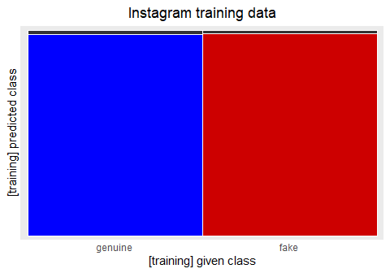

```r
stackedplot(vcrtrain, classCols = cols, main =
              "Instagram training data")
```

```
##  classNumber classLabel classSize classAveSi
##            1    genuine       288        0.9
##            2       fake       288        0.9
```

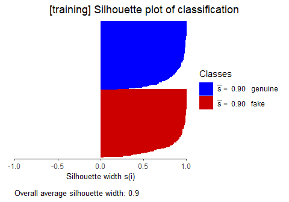

```r
# Silhouette plot:
silplot(vcrtrain, classCols = cols)
```

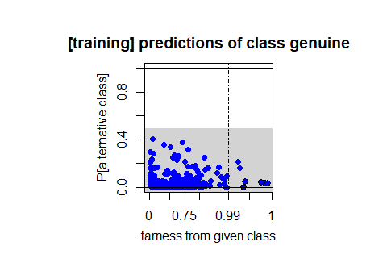

```r
# Here all the s(i) are nonnegative (due to overfitting).

# Class maps:
classmap(vcrtrain, "genuine", classCols = cols) #, identify = TRUE)
```

```r
# farness outliers from furthest to closer: 45, 25, 41
x_train[c(45, 25, 41), ] # they have huge numbers of followers.
```

```
##    profile.pic nums.length.username fullname.words nums.length.fullname
## 45           1                    0              4                    0
## 25           1                    0              0                    0
## 41           1                    0              0                    0
##    name..username description.length external.URL private X.posts X.followers
## 45              0                 35            0       0    4494    12397719
## 25              0                  0            0       0     148    15338538
## 41              0                  2            0       0    7389      890969
##    X.follows
## 45         8
## 25        61
## 41        11
```

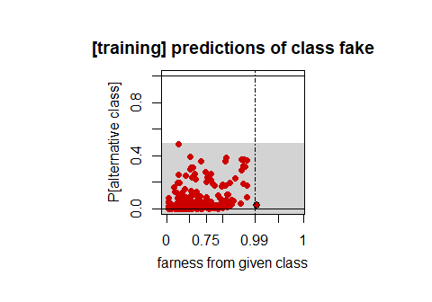

```r
classmap(vcrtrain, "fake", classCols = cols) #, identify = TRUE)
```

```r
# only case 261 is borderline far.
```

The classification of the training data is not very realistic due to overfitting, so let us look at the test data.

# Instagram test data

Now we consider the test data. First we load the data.

```r
testdata <- data_instagram[which(data_instagram$dataType == "test"), -13]
Xnew <- testdata[, -12]
ynew <- testdata[, 12]
```

We can now prepare for visualization:

```r
vcrtest <- vcr.forest.newdata(Xnew, ynew, vcrtrain)

confmat.vcr(vcrtest)
```

[output not shown]

First we visualize using the stacked plot and the silhouette plot:

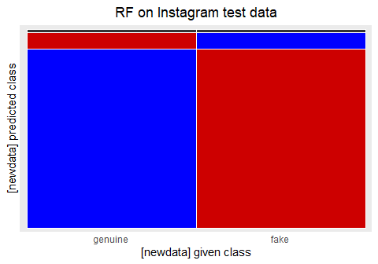

```r
stackedplot(vcrtest, classCols = cols,
            main = "RF on Instagram test data")
```

```
##  classNumber classLabel classSize classAveSi
##            1    genuine        60       0.75
##            2       fake        60       0.75
```

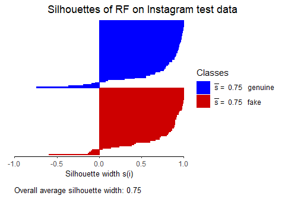

```r
# Silhouette plot:
silplot(vcrtest, classCols = cols, main =
          "Silhouettes of RF on Instagram test data") # now some s(i) are negative
```

Now we make the class maps

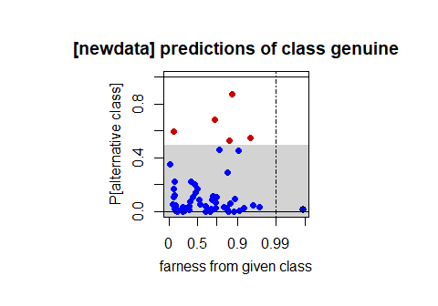

```r
## Class of genuine accounts:

classmap(vcrtest, "genuine", classCols = cols) #, identify = TRUE)
```

```r
# one farness outlier:
Xnew[c(30), ]
```

```
##     profile.pic nums.length.username fullname.words nums.length.fullname
## 606           1                    0              2                    0
##     name..username description.length external.URL private X.posts X.followers
## 606              0                147            1       0    1879     4021842
##     X.follows
## 606      5514
```

```r
# has very lengthy bio/description
# has large number of X.posts
# has very large number of followers and follows

# genuine misclassified as fake: from highest PAC to lowest
Xnew[c(21, 29, 51), ] # and 2 more borderline cases
```

```
##     profile.pic nums.length.username fullname.words nums.length.fullname
## 597           1                 0.50              1                    0
## 605           1                 0.33              1                    0
## 627           1                 0.00              3                    0
##     name..username description.length external.URL private X.posts X.followers
## 597              0                  0            0       1       0         189
## 605              0                  0            0       1       5         348
## 627              0                  0            0       0       9          62
##     X.follows
## 597       276
## 605       347
## 627        47
```

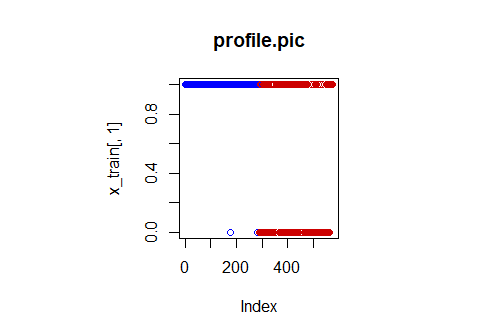

```r
# They have some unusual characteristics for their class:
# * 21, 29 have a (very) high nums.length.username, i.e. the
#   percentage of numerical characters in the username.
# * 21, 29 have a full name of only 1 word.
# * 21, 29 and 51 have description.length = 0, i.e. no
#   description/biography of their profile.
# * they all have low X.posts (even 0 for case 21), i.e.
#   relatively few previous posts.
# All of these characteristics are more common for fake profiles
# than for genuine profiles, as we can see below:

trcols <- cols[as.numeric(y_train)]

plot(x_train[, 1], col = trcols, main = "profile.pic")
```

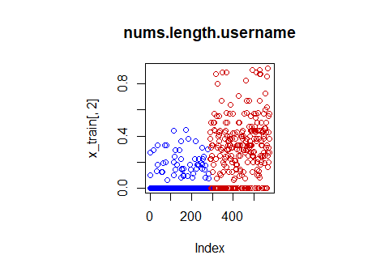

```r
# fakes are less likely to have a profile picture
plot(x_train[, 2], col = trcols, main = "nums.length.username")
```

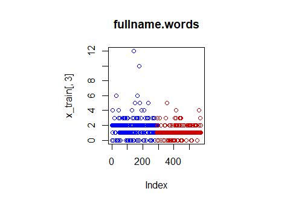

```r
# is higher for fakes
plot(x_train[, 3], col = trcols, main = "fullname.words")
```

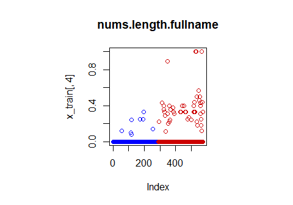

```r
# is lower for fakes
plot(x_train[, 4], col = trcols, main = "nums.length.fullname")
```